# Customer Churn Problem

## Problem Background

Customer churn is a problem that all companies need to monitor, especially those that depend on subscription-based revenue streams. Customer churn refers to the situation when a customer ends their relationship with a company, and it’s a costly problem. Customers are the fuel that powers a business. Loss of customers impacts sales. Further, it’s much more difficult and costly to gain new customers than it is to retain existing customers. As a result, organizations need to focus on reducing customer churn.

The dataset used for this Keras tutorial is IBM Watson Telco Dataset. According to IBM, the business challenge is:

“A telecommunications company [Telco] is concerned about the number of customers leaving their landline business for cable competitors. They need to understand who is leaving. Imagine that you’re an analyst at this company and you have to find out who is leaving and why.”

We are going to use Keras library to to develop a sophisticated and highly accurate deep learning model in R. We walk you through the preprocessing steps, investing time into how to format the data for Keras.

Finally we show you how to get black box (NN) insighrts using the recently developed lime package.

```r
# Load libraries

# install.packages("devtools")
#devtools::install_github("mdancho84/tidyquant")

library(keras) #modeling NN
library(tidyverse) #for data manipulation
library(rsample) #for sampling
library(recipes) #for eficient preprocessing
library(yardstick) #Tidy methods for measuring model performance
library(corrr) #for Correlation Analysis
library(readr)

# Install Keras if you have not installed before
#install_keras()
```

## Read Data

The dataset includes information about:

- Customers who left within the last month: The column is called Churn
- Services that each customer has signed up for: phone, multiple lines, internet, online security, online backup, device protection, tech support, and streaming TV and movies
- Customer account information: how long they’ve been a customer, contract, payment method, paperless billing, monthly charges, and total charges
- Demographic info about customers: gender, age range, and if they have partners and dependents

```r
#setwd("YOUR HOME DIRECTORY PATH")
churn_data_raw <- read_csv("Telco-Customer-Churn.csv")
head(churn_data_raw)
```

```
## # A tibble: 6 x 21
##   customerID gender SeniorCitizen Partner Dependents tenure PhoneService
##   <chr>      <chr>          <dbl> <chr>   <chr>       <dbl> <chr>
## 1 7590-VHVEG Female             0 Yes     No              1 No
## 2 5575-GNVDE Male               0 No      No             34 Yes
## 3 3668-QPYBK Male               0 No      No              2 Yes
## 4 7795-CFOCW Male               0 No      No             45 No
## 5 9237-HQITU Female             0 No      No              2 Yes
## 6 9305-CDSKC Female             0 No      No              8 Yes
## # … with 14 more variables: MultipleLines <chr>, InternetService <chr>,
## #   OnlineSecurity <chr>, OnlineBackup <chr>, DeviceProtection <chr>,
## #   TechSupport <chr>, StreamingTV <chr>, StreamingMovies <chr>,
## #   Contract <chr>, PaperlessBilling <chr>, PaymentMethod <chr>,
## #   MonthlyCharges <dbl>, TotalCharges <dbl>, Churn <chr>
```

## Prune and clean dataset

```r
churn_data_tbl <- churn_data_raw %>%
  select(-customerID) %>% # remove the customerID
  drop_na() %>%  # Drop rows that have NA(Not Available) Values
  select(Churn, everything())

head(churn_data_tbl) #dsiplay 6 first rows of the dataset.
```

```
## # A tibble: 6 x 20
##   Churn gender SeniorCitizen Partner Dependents tenure PhoneService
##   <chr> <chr>          <dbl> <chr>   <chr>       <dbl> <chr>
## 1 No    Female             0 Yes     No              1 No
## 2 No    Male               0 No      No             34 Yes
## 3 Yes   Male               0 No      No              2 Yes
## 4 No    Male               0 No      No             45 No
## 5 Yes   Female             0 No      No              2 Yes
## 6 Yes   Female             0 No      No              8 Yes
## # … with 13 more variables: MultipleLines <chr>, InternetService <chr>,
## #   OnlineSecurity <chr>, OnlineBackup <chr>, DeviceProtection <chr>,
## #   TechSupport <chr>, StreamingTV <chr>, StreamingMovies <chr>,
## #   Contract <chr>, PaperlessBilling <chr>, PaymentMethod <chr>,
## #   MonthlyCharges <dbl>, TotalCharges <dbl>
```

## Split data

Split test/training sets using the rsample package

```r
set.seed(1000) #for reproducibility
train_test_split <- initial_split(churn_data_tbl, prop = 0.8)
train_tbl <- training(train_test_split)
test_tbl  <- testing(train_test_split)
cat("Dimensions of the training set is: ", dim(train_tbl), "\n")
```

```
## Dimensions of the training set is:  5626 20
```

```r
cat("Dimensions of the test set is: ", dim(test_tbl), "\n")
```

```
## Dimensions of the test set is:  1406 20
```

## Preprocess/Normalize the Data using the friendly “recipe”

1. we discretize the variable *tenure* into 6 categories
2. create the log transformation of *TotalCharges*
3. encode the categorical data into dummy variables
4. to mean-center the data
5. scale the data
6. prepare the recipe, i.e., estimate the required parameters from a training set that can later be applied to other data sets

```r
# Create recipe
rec_obj <- recipe(Churn ~ ., data = train_tbl) %>%
  step_discretize(tenure, options = list(cuts = 6)) %>%
  step_log(TotalCharges) %>%
  step_dummy(all_nominal(), -all_outcomes()) %>%
  step_center(all_predictors(), -all_outcomes()) %>%
  step_scale(all_predictors(), -all_outcomes()) %>%
  prep(data = train_tbl)

# Print the recipe object
rec_obj
```

```
## Data Recipe
##
## Inputs:
##
##       role #variables
##    outcome          1
##  predictor         19
##
## Training data contained 5626 data points and no missing data.
##
## Operations:
##
## Dummy variables from tenure [trained]
## Log transformation on TotalCharges [trained]
## Dummy variables from gender, Partner, Dependents, tenure, ... [trained]
## Centering for SeniorCitizen, MonthlyCharges, ... [trained]
## Scaling for SeniorCitizen, MonthlyCharges, ... [trained]
```

We can apply the “recipe” to any data set with the bake() function, and it processes the data following our recipe steps above. We apply to our training and testing data to convert from raw data to a machine learning dataset.

And finaly, we need to store the actual (truth) values as y_train_vec and y_test_vec, which are needed for training and testing our NN.

```r
# Creating the X and Y sets
x_train_tbl <- bake(rec_obj, new_data = train_tbl) %>% select(-Churn)
x_test_tbl  <- bake(rec_obj, new_data = test_tbl) %>% select(-Churn)
glimpse(x_train_tbl)
```

```
## Observations: 5,626
## Variables: 35
## $ SeniorCitizen                         <dbl> -0.4415344, -0.4415344, -0.4415…
## $ MonthlyCharges                        <dbl> -1.160154536, -0.258911562, -0.…
## $ TotalCharges                          <dbl> -2.2865573014, 0.3963375852, 0.…
## $ gender_Male                           <dbl> -1.0138715, 0.9861429, 0.986142…
## $ Partner_Yes                           <dbl> 1.0424021, -0.9591522, -0.95915…
## $ Dependents_Yes                        <dbl> -0.6452448, -0.6452448, -0.6452…
## $ tenure_bin1                           <dbl> 2.1717829, -0.4603693, -0.46036…
## $ tenure_bin2                           <dbl> -0.4429705, -0.4429705, -0.4429…
## $ tenure_bin3                           <dbl> -0.4524097, -0.4524097, -0.4524…
## $ tenure_bin4                           <dbl> -0.4328828, 2.3096834, 2.309683…
## $ tenure_bin5                           <dbl> -0.4506983, -0.4506983, -0.4506…
## $ tenure_bin6                           <dbl> -0.4435444, -0.4435444, -0.4435…
## $ PhoneService_Yes                      <dbl> -3.0346152, 0.3294725, -3.03461…
```

[output cut: 22 more lines]

```r
y_train_vec <- ifelse(pull(train_tbl, Churn) == "Yes", 1, 0)
y_test_vec  <- ifelse(pull(test_tbl, Churn) == "Yes", 1, 0)
```

## Build the NN model

Finally, Deep Learning with Keras in R!

The first step is to initialize a sequential model with keras_model_sequential(), which is the beginning of our Keras model. The sequential model is composed of a linear stack (sequence) of layers.

*note*: The first layer needs to have the input_shape, that is the numeber of geatures that is getting fed by. In this case it is the number of columns in the x_train_tbl.

```r
# Building our Artificial Neural Network
model_keras <- keras_model_sequential()

model_keras %>%

  # First hidden layer
  layer_dense(
    units              = 16,
    kernel_initializer = "uniform",
    activation         = "relu",
    input_shape        = ncol(x_train_tbl)) %>%

  # Dropout to prevent overfitting
  layer_dropout(rate = 0.1) %>%

  # Second hidden layer
  layer_dense(
    units              = 16,
    kernel_initializer = "uniform",
    activation         = "relu") %>%

  # Dropout to prevent overfitting
  layer_dropout(rate = 0.1) %>%

  # Output layer
  layer_dense(
    units              = 1, #For multi-classification, the units should correspond to the number of classes
    kernel_initializer = "uniform",
    activation         = "sigmoid") %>%

  # Compile NN
  compile(
    optimizer = 'adam',
    loss      = 'binary_crossentropy',
    metrics   = c('accuracy')
  )

#display model architecture
model_keras
```

```
## Model
## Model: "sequential"
## ________________________________________________________________________________
## Layer (type)                        Output Shape                    Param #
## ================================================================================
## dense (Dense)                       (None, 16)                      576
## ________________________________________________________________________________
## dropout (Dropout)                   (None, 16)                      0
## ________________________________________________________________________________
## dense_1 (Dense)                     (None, 16)                      272
## ________________________________________________________________________________
## dropout_1 (Dropout)                 (None, 16)                      0
## ________________________________________________________________________________
## dense_2 (Dense)                     (None, 1)                       17
## ================================================================================
## Total params: 865
## Trainable params: 865
## Non-trainable params: 0
## ________________________________________________________________________________
```

```r
# Train model
history <- fit(
  object           = model_keras,
  x                = as.matrix(x_train_tbl),
  y                = y_train_vec,
  batch_size       = 50,
  epochs           = 35,
  validation_split = 0.30 #to include 30% of the data for model validation, which prevents overfitting.
)
```

```r
# Print a summary of the training history
print(history)
```

```
## Trained on 3,938 samples (batch_size=50, epochs=35)
## Final epoch (plot to see history):
##         loss: 0.396
##     accuracy: 0.8179
##     val_loss: 0.434
## val_accuracy: 0.8069
```

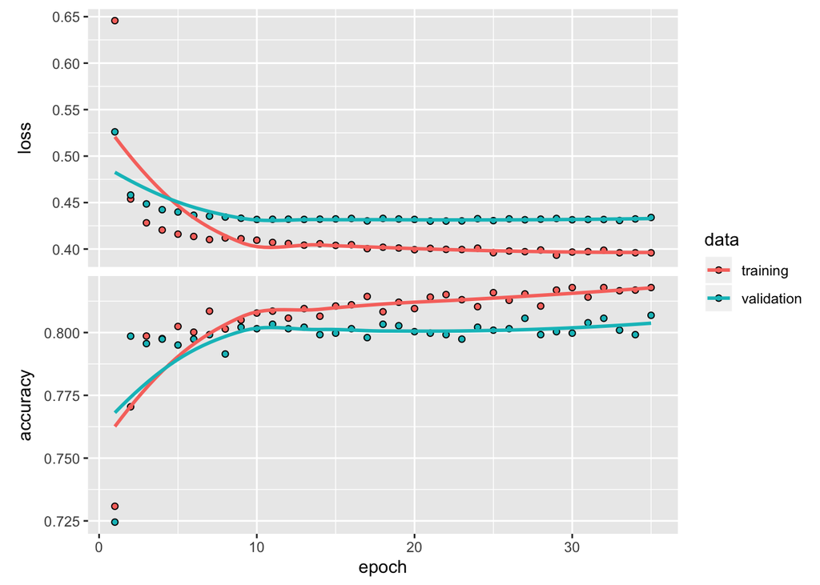

```r
# Plot the training/validation history of our Keras model
plot(history)
```

*Tip* Only use enough epochs to get a high validation accuracy. Once validation accuracy curve begins to flatten or decrease, it’s time to stop training.

let’s make some predictions from our keras model on the test data set, which was unseen during modeling. You can prdict *class* or *probability*

```r
# Predicted Class
yhat_keras_class_vec <- predict_classes(object = model_keras, x = as.matrix(x_test_tbl)) %>%
    as.vector()

# Predicted Class Probability
yhat_keras_prob_vec  <- predict_proba(object = model_keras, x = as.matrix(x_test_tbl)) %>%
    as.vector()
```

## Inspect Performance With Yardstick

```r
# Format test data and predictions for yardstick metrics
estimates_keras_tbl <- tibble(
  truth      = as.factor(y_test_vec) %>% fct_recode(yes = "1", no = "0"),
  estimate   = as.factor(yhat_keras_class_vec) %>% fct_recode(yes = "1", no = "0"),
  class_prob = yhat_keras_prob_vec
)
options(yardstick.event_first = FALSE) # the default is to classify 0 as the positive class instead of 1
estimates_keras_tbl
```

```
## # A tibble: 1,406 x 3
##    truth estimate class_prob
##    <fct> <fct>         <dbl>
##  1 yes   no          0.245
##  2 yes   yes         0.694
##  3 no    no          0.00814
##  4 no    no          0.0850
##  5 no    no          0.321
##  6 yes   yes         0.745
##  7 no    no          0.244
##  8 yes   yes         0.736
##  9 no    no          0.222
## 10 no    no          0.379
## # … with 1,396 more rows
```

### Confusion Table

```r
estimates_keras_tbl %>% conf_mat(truth, estimate)
```

```
##           Truth
## Prediction  no yes
##        no  951 181
##        yes  86 188
```

### Accuracy

```r
estimates_keras_tbl %>% accuracy(truth, estimate)
```

```
## # A tibble: 1 x 3
##   .metric  .estimator .estimate
##   <chr>    <chr>          <dbl>
## 1 accuracy binary         0.810
```

### AUC

ROC Area Under the Curve (AUC) measurement

```r
estimates_keras_tbl %>% roc_auc(truth, class_prob)
```

```
## # A tibble: 1 x 3
##   .metric .estimator .estimate
##   <chr>   <chr>          <dbl>
## 1 roc_auc binary         0.850
```

### Precision and Recall

Precision is when the model predicts “yes”, how often is it actually “yes”. Recall (also true positive rate) is when the actual value is “yes” how often is the model correct

```r
estimates_keras_tbl %>% precision(truth, estimate)
```

```
## # A tibble: 1 x 3
##   .metric   .estimator .estimate
##   <chr>     <chr>          <dbl>
## 1 precision binary         0.686
```

```r
estimates_keras_tbl %>% recall(truth, estimate)
```

```
## # A tibble: 1 x 3
##   .metric .estimator .estimate
##   <chr>   <chr>          <dbl>
## 1 recall  binary         0.509
```

### F1 Score

weighted average between the precision and recal

```r
estimates_keras_tbl %>% f_meas(truth, estimate)
```

```
## # A tibble: 1 x 3
##   .metric .estimator .estimate
##   <chr>   <chr>          <dbl>
## 1 f_meas  binary         0.585
```